# matplotlib.colors.BoundaryNorm

**class*matplotlib.colors.BoundaryNorm(*boundaries*, *ncolors*, *clip=False*, *, *extend='neither'*)[[source]](https://github.com/matplotlib/matplotlib/blob/v3.7.1/lib/matplotlib/colors.py#L1921-L2046)**

Bases: `Normalize`

Generate a colormap index based on discrete intervals.

Unlike `Normalize` or `LogNorm`, `BoundaryNorm` maps values to integers instead of to the interval 0-1.

**Parameters:**

**boundaries**array-like**

Monotonically increasing sequence of at least 2 bin edges: data falling in the n-th bin will be mapped to the n-th color.

**ncolors**int**

Number of colors in the colormap to be used.

**clip**bool, optional**

If clip is `True`, out of range values are mapped to 0 if they are below `boundaries[0]` or mapped to `ncolors - 1` if they are above `boundaries[-1]`.

If clip is `False`, out of range values are mapped to -1 if they are below `boundaries[0]` or mapped to *ncolors* if they are above `boundaries[-1]`. These are then converted to valid indices by `Colormap.__call__`.

**extend**{'neither', 'both', 'min', 'max'}, default: 'neither'**

Extend the number of bins to include one or both of the regions beyond the boundaries. For example, if `extend` is 'min', then the color to which the region between the first pair of boundaries is mapped will be distinct from the first color in the colormap, and by default a `Colorbar` will be drawn with the triangle extension on the left or lower end.

#### Notes

If there are fewer bins (including extensions) than colors, then the color index is chosen by linearly interpolating the `[0, nbins - 1]` range onto the `[0, ncolors - 1]` range, effectively skipping some colors in the middle of the colormap.

**__call__(*value*, *clip=None*)[[source]](https://github.com/matplotlib/matplotlib/blob/v3.7.1/lib/matplotlib/colors.py#L1996-L2036)**

This method behaves similarly to `Normalize.__call__`, except that it returns integers or arrays of int16.

**inverse(*value*)[[source]](https://github.com/matplotlib/matplotlib/blob/v3.7.1/lib/matplotlib/colors.py#L2038-L2046)**

**Raises:**

**ValueError**

BoundaryNorm is not invertible, so calling this method will always raise an error

## Examples using `matplotlib.colors.BoundaryNorm`

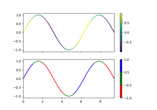

[Multicolored lines](https://matplotlib.org/stable/gallery/lines_bars_and_markers/multicolored_line.html#sphx-glr-gallery-lines-bars-and-markers-multicolored-line-py)

Multicolored lines

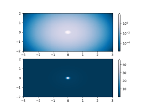

[Colormap normalizations](https://matplotlib.org/stable/gallery/images_contours_and_fields/colormap_normalizations.html#sphx-glr-gallery-images-contours-and-fields-colormap-normalizations-py)

Colormap normalizations

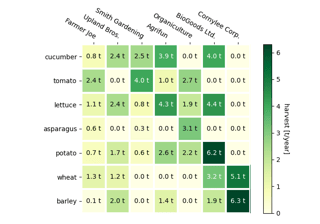

[Creating annotated heatmaps](https://matplotlib.org/stable/gallery/images_contours_and_fields/image_annotated_heatmap.html#sphx-glr-gallery-images-contours-and-fields-image-annotated-heatmap-py)

Creating annotated heatmaps

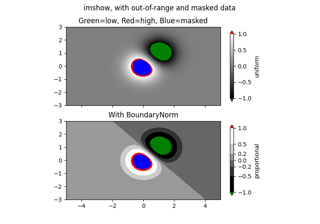

[Image Masked](https://matplotlib.org/stable/gallery/images_contours_and_fields/image_masked.html#sphx-glr-gallery-images-contours-and-fields-image-masked-py)

Image Masked

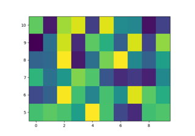

[pcolormesh](https://matplotlib.org/stable/gallery/images_contours_and_fields/pcolormesh_levels.html#sphx-glr-gallery-images-contours-and-fields-pcolormesh-levels-py)

pcolormesh

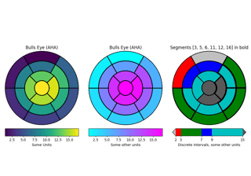

[Left ventricle bullseye](https://matplotlib.org/stable/gallery/specialty_plots/leftventricle_bullseye.html#sphx-glr-gallery-specialty-plots-leftventricle-bullseye-py)

Left ventricle bullseye

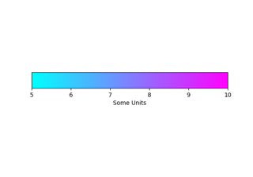

[Customized Colorbars Tutorial](https://matplotlib.org/stable/tutorials/colors/colorbar_only.html#sphx-glr-tutorials-colors-colorbar-only-py)

Customized Colorbars Tutorial

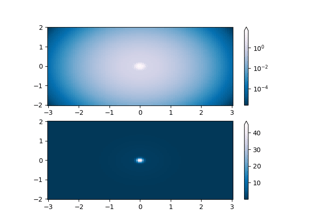

[Colormap Normalization](https://matplotlib.org/stable/tutorials/colors/colormapnorms.html#sphx-glr-tutorials-colors-colormapnorms-py)

Colormap Normalization

© 2012–2023 Matplotlib Development Team. All rights reserved.  
Licensed under the Matplotlib License Agreement.  
https://matplotlib.org/stable/api/_as_gen/matplotlib.colors.BoundaryNorm.html